# Title

## df: 새로운 열의 할당 1단계

### 방법1: concat

### 방법2: 4가지 컨셉에 따른 할당

#### `#` 컨셉1: 불가능

#### `#` 컨셉2: 가능

(예시1)

(예시2)

(예시3)

#### `#` 컨셉3: 불가능

(예시1)

#### `#` 컨셉4: 가능

(예시1)

(예시2)

(예시3)

### 방법3: `.assign`으로 할당 ($\star$) -- 제 최애

(예시1)

(예시2)

(예시3)

### 방법4: `.eval`을 이용한 할당

(예시1)

(예시2)

(예시3)

### 연습해보기

#### `#` 데이터프레임 생성

```python
df=pd.DataFrame({'x':np.random.randn(1000),'y':np.random.randn(1000)})
df
```

|  | x | y |
| --- | --- | --- |
| 0 | -0.764383 | -0.210562 |
| 1 | 0.158599 | 0.519075 |
| 2 | 1.310067 | 1.195781 |
| 3 | 1.218756 | -0.461920 |
| 4 | -0.659421 | -1.291390 |
| ... | ... | ... |
| 995 | 0.785107 | 0.389029 |
| 996 | -0.336152 | -0.069667 |
| 997 | -0.102498 | -1.220610 |
| 998 | -0.529699 | -0.718744 |
| 999 | 0.943236 | 1.015053 |

1000 rows × 2 columns

## 아이스크림을 많이 먹으면 걸리는 병

`-` ref- [데이터 과학자의 사고법: 더 나은 선택을 위한 통계학적 통찰의 힘](https://github.com/guebin/DV2022/blob/master/_notebooks/ds.pdf)

- 구매할만한 책입니다

`-` 내용요약

- 여름 $\to$ 수영장 $\to$ 소아마비
- 여름 $\to$ 아이스크림
- 아이스크림과 소아마비는 상관관계가 높다: 아이스크림 성분중에서 소아마비를 유발하는 유해물질이 있을 것이다 (?)

`-` 아래와 같이 모형을 간단하게 하자.

- 온도 $\to$ 소아마비
- 온도 $\to$ 아이스크림

### Toy exam

`-` 교재의 예제상황은 예를들면 아래와 같다.

(숨은진짜상황1)

$$\text{아이스크림 판매량} = 20 + 2 \times \text{온도} + \epsilon$$

```python
np.random.seed(1)
temp= np.array([-10.2, -5.2, 0.1, 10.1, 12.2, 14.7,
                25.4, 26.8, 28.9, 35.1, 32.2, 34.6])
eps= np.random.normal(size=12,scale=5)
icecream= 20 + temp * 2 + eps
```

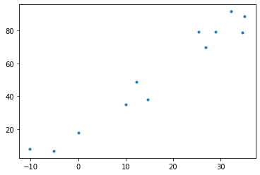

```python
plt.plot(temp,icecream,'.')
```

- 온도와 아이스크림 판매량의 산점도

(숨은진짜상황2)

`-` 소아마비 = 30 + 온도 $\times$ 0.5 + $\epsilon^*$

- 좌변의 "소아마비"는 소아마비임을 나타내는 어떠한 반응수치라고 생각하자.

```python
np.random.seed(2)
eps = np.random.normal(size=12,scale=5)
disease = 30+ temp* 0.5 + eps
```

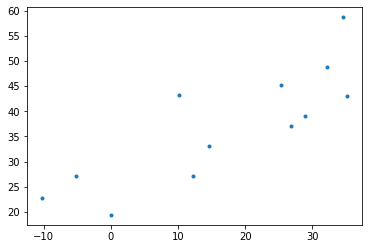

```python
plt.plot(temp,disease,'.')
```

- 온도와 소아마비의 산점도

**(우리가 데이터로부터 관측한 상황)**

`-` 아이스크림과 질병의 산점도를 그려보자.

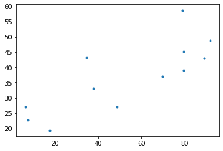

```python
plt.plot(icecream,disease,'.')
```

- 양의 상관관계에 있다.

`-` 아이스크림 중 어떠한 물질이 소아마비를 일으키는것이 분명하므로 (인과성이 분명해보이니까) 아래와 같은 모형을 세우자. <-- 여기서부터 틀렸음

$${\tt disease}_i =\beta_0 +\beta_1 {\tt icecream}_i +\epsilon_i,\quad \textbf{for} ~~ i=1,2,\dots, 12$$

`-` 적절한 $\beta_0$와 $\beta_1$을 추정하면 우리는 아이스크림과 소아마비의 관계를 알 수 있다. <-- 틀린주장

- 틀린 모형
- 도데체 우리가 뭘 잘못했는가?

`-` 두 변수 사이에 상관관계가 있어도 실제 원인은 다른 변수에 숨겨져 있는 경우가 많다.

(ex1)

- 온도 $\to$ 익사
- 온도 $\to$ 아이스크림
- 아이스크림과 익사자도 양의 상관관계에 있을것이다.
- 아이스크림을 먹이면 물에 빠져 죽는다 $\to$ 틀린주장
- 사실 기온이 숨겨진 원인이다. 기온이 증가하면 아이스크림 판매량도 증가하고 폭염때문에 익사사고율도 높아지는 구조이다.

(ex2)

- 인구수 $\to$ 교회
- 인구수 $\to$ 범죄건수
- 지역별 교회와 범죄건수를 살펴보면 상관관계가 높게 나올것임
- 교회를 지으면 범죄건수도 증가한다? $\to$ 틀린주장
- 사실 인구가 숨겨진 요인임

`-` ex2, ex1에 대하여 바른 분석을 하려면?

- ex2: 인구가 비슷한 도시끼리 묶어서 비교해보면 교회와 범죄의 건수는 양의 상관관계에 있지 않을것임
- ex1: 온도가 비슷한 그룹끼리 묶어보자.

`-` 올바른 분석: 온도가 비슷한 그룹끼리 묶어서 그려보자. $\to$ 상관계수가 줄어들 것이다.

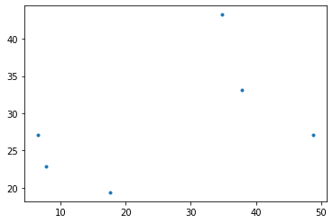

```python
plt.plot(icecream[:6],disease[:6],'.')
```

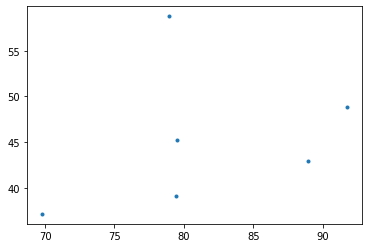

```python
plt.plot(icecream[6:],disease[6:],'.')
```

- 진짜로 선형관계가 약해졌다..

### 좀 더 그럴듯한 자료

`-` 위의 toy example은 데이터가 너무 작아서 억지스러움

```python
df=pd.read_csv('https://raw.githubusercontent.com/guebin/2021DV/master/_notebooks/extremum.csv')
```

```python
df
```

|  | 지점번호 | 지점명 | 일시 | 평균기온(℃) | 최고기온(℃) | 최고기온시각 | 최저기온(℃) | 최저기온시각일교차 | Unnamed: 8 |
| --- | --- | --- | --- | --- | --- | --- | --- | --- | --- |
| 0 | 146 | 전주 | 2020-01-01 | -0.5 | 4.3 | 15:09 | -6.4 | 1:42 | 10.7 |
| 1 | 146 | 전주 | 2020-01-02 | 1.4 | 6.5 | 14:12 | -3.0 | 7:55 | 9.5 |
| 2 | 146 | 전주 | 2020-01-03 | 2.6 | 7.6 | 13:32 | -0.5 | 23:53 | 8.1 |
| 3 | 146 | 전주 | 2020-01-04 | 2.0 | 7.7 | 13:51 | -2.6 | 5:30 | 10.3 |
| 4 | 146 | 전주 | 2020-01-05 | 2.5 | 8.6 | 14:05 | -3.2 | 7:36 | 11.8 |
| ... | ... | ... | ... | ... | ... | ... | ... | ... | ... |
| 651 | 146 | 전주 | 2021-10-13 | 19.9 | 25.5 | 14:29 | 15.6 | 3:49 | 9.9 |
| 652 | 146 | 전주 | 2021-10-14 | 20.4 | 25.5 | 13:36 | 17.0 | 6:15 | 8.5 |
| 653 | 146 | 전주 | 2021-10-15 | 18.3 | 22.0 | 13:47 | 15.7 | 4:48 | 6.3 |
| 654 | 146 | 전주 | 2021-10-16 | 12.8 | 17.4 | 0:01 | 6.5 | 23:31 | 10.9 |
| 655 | 146 | 전주 | 2021-10-17 | 6.7 | 12.4 | 15:18 | 2.2 | 6:43 | 10.2 |

656 rows × 9 columns

`-` 평균기온만 선택하여 뽑자.

```python
dict(pd.Series(df.columns))
```

```
{0: '지점번호',
 1: '지점명',
 2: '일시',
 3: '평균기온(℃)',
 4: '최고기온(℃)',
 5: '최고기온시각',
 6: '최저기온(℃)',
 7: '최저기온시각일교차',
 8: 'Unnamed: 8'}
```

```python
temp=np.array(df.iloc[:,3])
```

`-` (숨은진짜상황1) 온도 vs 아이스크림 판매량

```python
np.random.seed(1)
eps=np.random.normal(size=656, scale=10)
icecream=temp*2 + 30 + eps
```

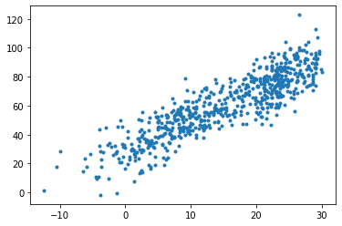

```python
plt.plot(temp,icecream,'.')
```

`-` (숨은진짜상황2) 온도 vs 소아마비

```python
np.random.seed(2)
eps=np.random.normal(size=656,scale=1)
disease=temp*0.5 + 40 +eps
```

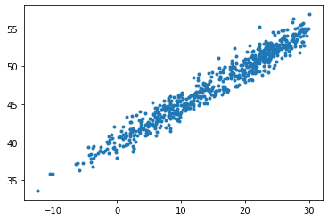

```python
plt.plot(temp,disease,'.')
```

`-` (우리가 관측한 상황) 아이스크림판매량 vs 소아마비

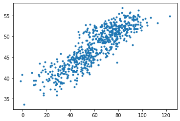

```python
plt.plot(icecream,disease,'.')
```

```python
np.corrcoef(icecream,disease)
```

```
array([[1.        , 0.86298975],
       [0.86298975, 1.        ]])
```

- 0.86정도..

`-` 여름만 뽑아서 그러보면? (temp>25 인것만 뽑아서 그려보면?)

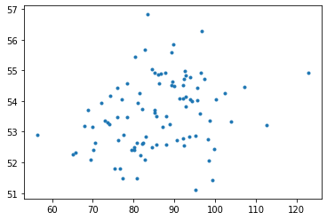

```python
plt.plot(icecream[temp>25],disease[temp>25], '.') ## 평균기온이 25도가 넘어가면 여름으로 생각하자.
```

- 이제 아이스크림판매량과 소아마비는 별로 상관이 없어보인다.

`-` 산점도

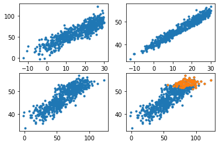

```python
fig , ((ax1,ax2), (ax3,ax4)) = plt.subplots(2,2)
ax1.plot(temp,icecream,'.')
ax2.plot(temp,disease,'.')
ax3.plot(icecream,disease,'.')
ax4.plot(icecream,disease,'.')
ax4.plot(icecream[temp>25],disease[temp>25],'.')
```

### 온도구간을 세분화 하여 시각화

`-` 목표: 모든 온도구간에 대하여 각각 색을 다르게 하여 그려보자.

- 사실 지금 변수는 온도, 아이스크림판매량, 소아마비
- 지금까지는 기본산점도만 사용하였기에 2차원플랏만 그렸음 $\to$ 그래서 각각의 산점도를 정신없이 그려왔음
- 온도가 유사한 지역을 색으로 묶으면 3차원 플랏이 가능함

`-` 일단 데이터 프레임을 정리하자.

```python
df1=pd.DataFrame({'temp':temp, 'icecream':icecream, 'disease':disease})
```

```python
df1
```

|  | temp | icecream | disease |
| --- | --- | --- | --- |
| 0 | -0.5 | 45.243454 | 39.333242 |
| 1 | 1.4 | 26.682436 | 40.643733 |
| 2 | 2.6 | 29.918282 | 39.163804 |
| 3 | 2.0 | 23.270314 | 42.640271 |
| 4 | 2.5 | 43.654076 | 39.456564 |
| ... | ... | ... | ... |
| 651 | 19.9 | 78.839992 | 49.633906 |
| 652 | 20.4 | 86.554679 | 48.920443 |
| 653 | 18.3 | 78.666079 | 49.882650 |
| 654 | 12.8 | 52.771364 | 46.613159 |
| 655 | 6.7 | 40.736731 | 44.902513 |

656 rows × 3 columns

`-` 온도를 카테고리화 하자 $\to$ 적당한 구긴을 설정하기 위해서 히스토그램을 그려보자.

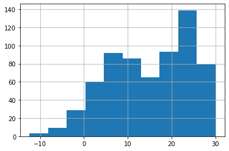

```python
df1.temp.hist()
```

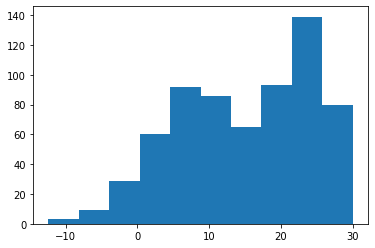

```python
plt.hist(df1.temp)
```

`-` 구간은 5정도로 하면 적당할것 같다.

```python
def f(x):
    if x<0:
        y='Temp: <0'
    elif x<5:
        y='Temp: 0~5'
    elif x<10:
        y='Temp: 5~10'
    elif x<15:
        y='Temp: 10~15'
    elif x<20:
        y='Temp: 15~20'
    elif x<25:
        y='Temp: 20~25'
    else:
        y='Temp: >30'
    return y
```

```python
df1['temp2']=list(map(f,df1.temp))
```

```python
df1
```

|  | temp | icecream | disease | temp2 |
| --- | --- | --- | --- | --- |
| 0 | -0.5 | 45.243454 | 39.333242 | Temp: <0 |
| 1 | 1.4 | 26.682436 | 40.643733 | Temp: 0~5 |
| 2 | 2.6 | 29.918282 | 39.163804 | Temp: 0~5 |
| 3 | 2.0 | 23.270314 | 42.640271 | Temp: 0~5 |
| 4 | 2.5 | 43.654076 | 39.456564 | Temp: 0~5 |
| ... | ... | ... | ... | ... |
| 651 | 19.9 | 78.839992 | 49.633906 | Temp: 15~20 |
| 652 | 20.4 | 86.554679 | 48.920443 | Temp: 20~25 |
| 653 | 18.3 | 78.666079 | 49.882650 | Temp: 15~20 |
| 654 | 12.8 | 52.771364 | 46.613159 | Temp: 10~15 |
| 655 | 6.7 | 40.736731 | 44.902513 | Temp: 5~10 |

656 rows × 4 columns

```python
from plotnine import *
```

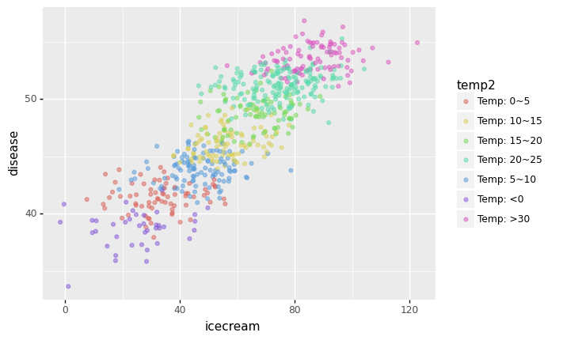

```python
ggplot(data=df1)+geom_point(aes(x='icecream',y='disease',colour='temp2'),alpha=0.5)
```

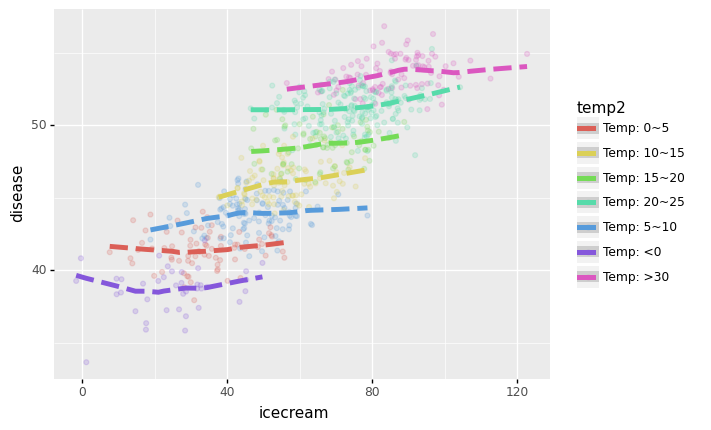

```python
ggplot(data=df1)+geom_point(aes(x='icecream',y='disease',colour='temp2'),alpha=0.2)+geom_smooth(aes(x='icecream',y='disease',colour='temp2'),size=2,linetype='dashed')
```

`-` 온도를 통제하니까 아이스크림과 질병은 관련이 없어보인다.

### 진짜 만약에 아이스크림과 소아마비가 관련있는 경우라면?

```python
np.random.seed(1)
eps=np.random.normal(size=656, scale=10)
icecream=temp*2 + 30 + eps
```

```python
np.random.seed(2)
eps=np.random.normal(size=656,scale=2)
disease= 30+ temp*0.0 + icecream*0.15 + eps
```

```python
df2=pd.DataFrame({'temp':temp,'icecream':icecream,'disease':disease})
df2['temp2']=list(map(f,df2.temp))
```

```python
df2
```

|  | temp | icecream | disease | temp2 |
| --- | --- | --- | --- | --- |
| 0 | -0.5 | 45.243454 | 35.953002 | Temp: <0 |
| 1 | 1.4 | 26.682436 | 33.889832 | Temp: 0~5 |
| 2 | 2.6 | 29.918282 | 30.215350 | Temp: 0~5 |
| 3 | 2.0 | 23.270314 | 36.771089 | Temp: 0~5 |
| 4 | 2.5 | 43.654076 | 32.961240 | Temp: 0~5 |
| ... | ... | ... | ... | ... |
| 651 | 19.9 | 78.839992 | 41.193811 | Temp: 15~20 |
| 652 | 20.4 | 86.554679 | 40.424088 | Temp: 20~25 |
| 653 | 18.3 | 78.666079 | 43.265212 | Temp: 15~20 |
| 654 | 12.8 | 52.771364 | 38.342022 | Temp: 10~15 |
| 655 | 6.7 | 40.736731 | 39.215537 | Temp: 5~10 |

656 rows × 4 columns

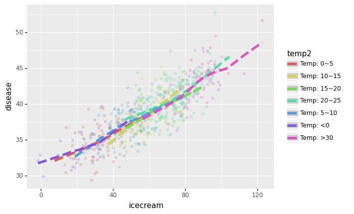

```python
ggplot(data=df2)+geom_point(aes(x='icecream',y='disease',colour='temp2'),alpha=0.2)+geom_smooth(aes(x='icecream',y='disease',colour='temp2'),size=2,linetype='dashed')
```

```python
df1.corr()
```

|  | temp | icecream | disease |
| --- | --- | --- | --- |
| temp | 1.000000 | 0.884366 | 0.975609 |
| icecream | 0.884366 | 1.000000 | 0.862990 |
| disease | 0.975609 | 0.862990 | 1.000000 |

```python
df2.corr()
```

|  | temp | icecream | disease |
| --- | --- | --- | --- |
| temp | 1.000000 | 0.884366 | 0.725505 |
| icecream | 0.884366 | 1.000000 | 0.830539 |
| disease | 0.725505 | 0.830539 | 1.000000 |

## FIFA 선수들 시각화

### FIFA data

`-` FIFA22라는 축구게임이 있음 (굉장히 인기있음)

`-` 게임에 실제 선수들이 나오면서 선수들의 능력치가 세밀하게 구현되어 있음

`-` 이 능력치에 대한 데이터셋은 캐글에 공개되어 있음

### Data

```python
fifa22=pd.read_csv('https://raw.githubusercontent.com/guebin/2021DV/master/_notebooks/2021-10-25-FIFA22_official_data.csv')
```

`-` Overall을 기준으로 정렬하여 보자.

```python
fifa22=fifa22.sort_values(by='Overall',ascending=False).reset_index().rename(columns={'index':'index_old'})
```

```python
fifa22.head()
```

|  | index_old | ID | Name | Age | Photo | Nationality | Flag | Overall | Potential | Club | ... | SlidingTackle | GKDiving | GKHandling | GKKicking | GKPositioning | GKReflexes | Best Position | Best Overall Rating | Release Clause | DefensiveAwareness |
| --- | --- | --- | --- | --- | --- | --- | --- | --- | --- | --- | --- | --- | --- | --- | --- | --- | --- | --- | --- | --- | --- |
| 0 | 29 | 158023 | L. Messi | 34 | https://cdn.sofifa.com/players/158/023/22_60.png | Argentina | https://cdn.sofifa.com/flags/ar.png | 93 | 93 | Paris Saint-Germain | ... | 24.0 | 6.0 | 11.0 | 15.0 | 14.0 | 8.0 | RW | 93.0 | €144.3M | 20.0 |
| 1 | 33 | 188545 | R. Lewandowski | 32 | https://cdn.sofifa.com/players/188/545/22_60.png | Poland | https://cdn.sofifa.com/flags/pl.png | 92 | 92 | FC Bayern München | ... | 19.0 | 15.0 | 6.0 | 12.0 | 8.0 | 10.0 | ST | 92.0 | €197.2M | 35.0 |
| 2 | 14244 | 200389 | J. Oblak | 28 | https://cdn.sofifa.com/players/200/389/22_60.png | Slovenia | https://cdn.sofifa.com/flags/si.png | 91 | 93 | Atlético de Madrid | ... | 18.0 | 87.0 | 92.0 | 78.0 | 90.0 | 90.0 | GK | 91.0 | €238M | 27.0 |
| 3 | 3 | 192985 | K. De Bruyne | 30 | https://cdn.sofifa.com/players/192/985/22_60.png | Belgium | https://cdn.sofifa.com/flags/be.png | 91 | 91 | Manchester City | ... | 53.0 | 15.0 | 13.0 | 5.0 | 10.0 | 13.0 | CM | 91.0 | €232.2M | 68.0 |
| 4 | 64 | 190871 | Neymar Jr | 29 | https://cdn.sofifa.com/players/190/871/22_60.png | Brazil | https://cdn.sofifa.com/flags/br.png | 91 | 91 | Paris Saint-Germain | ... | 29.0 | 9.0 | 9.0 | 15.0 | 15.0 | 11.0 | LW | 91.0 | €238.7M | 35.0 |

5 rows × 66 columns

### Overall vs Potential

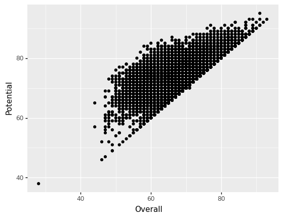

```python
ggplot(data=fifa22)+geom_point(aes(x='Overall', y='Potential'))
```

`-` 뭔가 Potential > Overall 인 관계가 성립하는것 같다. $\to$ Potetial_Delta = Potential - Overall 인 변수를 새로 만들고 시각화해보자.

- 판다스: 새로운열 추가

```python
fifa22['Potential_Delta'] = fifa22['Potential'] - fifa22['Overall']
```

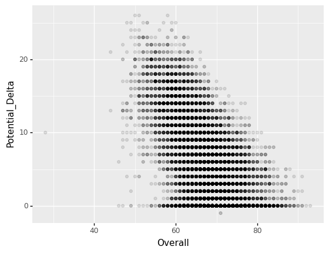

```python
ggplot(data=fifa22)+geom_point(aes(x='Overall', y='Potential_Delta'),alpha=0.1)
```

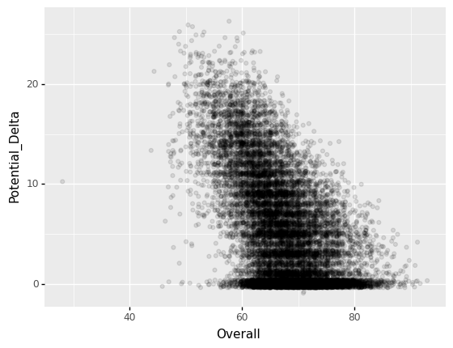

```python
ggplot(data=fifa22)+geom_point(aes(x='Overall', y='Potential_Delta'),alpha=0.1,position='jitter')
```

`-` Potential_Delta가 너무 0근처인 선수들이 있다. (아마 은퇴한 선수가 아닐까?) $\to$ 제외하고 그리자.

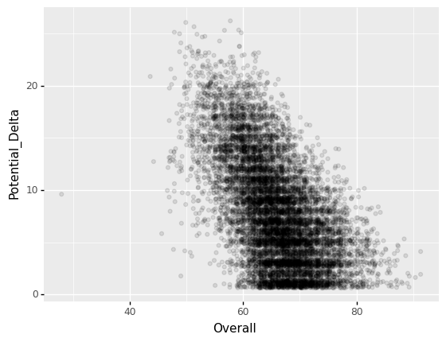

```python
ggplot(data=fifa22.query('Potential_Delta>0.1'))+geom_point(aes(x='Overall', y='Potential_Delta'),alpha=0.1,position='jitter')
```

`-` 해석

- 음의 상관관계가 있다.
- 오버올이 클수록 Potential_Delta의 분산이 작아진다. (오버올이 클수록 더 성장할 부분이 없으니까)

`-` Overall을 구간별로 나누자: 어느정도가 적당한 구간일까?

```python
fifa22.Overall.describe()
```

```
count    16710.000000
mean        67.646320
std          6.457695
min         28.000000
25%         63.000000
50%         68.000000
75%         72.000000
max         93.000000
Name: Overall, dtype: float64
```

```python
import matplotlib.pyplot as plt
```

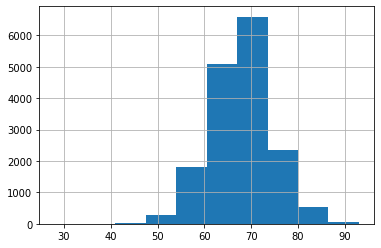

```python
fifa22.Overall.hist()
```

```python
def f(x):
    if x>72: y='Q1'
    elif x>68: y='Q2'
    elif x>63: y='Q3'
    else: y='Q4'
    return y
```

```python
fifa22['Q']=list(map(f,fifa22.Overall))
fifa22[['Q','Overall']]
```

|  | Q | Overall |
| --- | --- | --- |
| 0 | Q1 | 93 |
| 1 | Q1 | 92 |
| 2 | Q1 | 91 |
| 3 | Q1 | 91 |
| 4 | Q1 | 91 |
| ... | ... | ... |
| 16705 | Q4 | 46 |
| 16706 | Q4 | 46 |
| 16707 | Q4 | 44 |
| 16708 | Q4 | 44 |
| 16709 | Q4 | 28 |

16710 rows × 2 columns

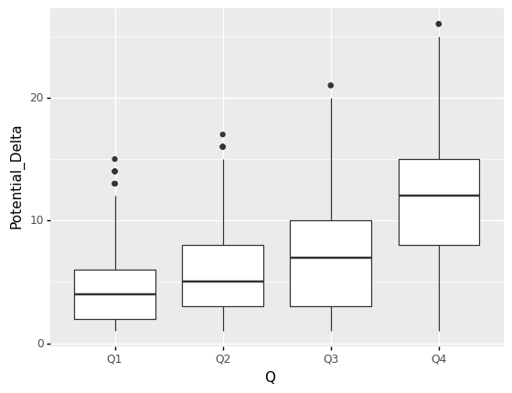

```python
ggplot(data=fifa22.query('Potential_Delta>0.1'))\
+geom_boxplot(aes(x='Q',y='Potential_Delta'))
```

`-` Q1으로 갈수록 분산이 작아짐! $\to$ 헷갈린다...

`-` 산점도와 박스플랏을 겹쳐서 그린다면 좀더 이해가 쉬울것 같다.

`-` x축의 위치를 조정하면 될것 같다 $\to$ Q1, Q2, Q3, Q4 각 그룹별로 x축의 위치를 구하자.

```python
fifa22.query('Q=="Q1"').Overall.mean()
```

```
76.3506528835691
```

- 이런식으로 해도 되지만

```python
fifa22.groupby(by='Q').mean().Overall
```

```
Q
Q1    76.350653
Q2    70.411781
Q3    66.074449
Q4    59.602691
Name: Overall, dtype: float64
```

```python
l=fifa22.groupby(by='Q').mean().Overall.to_list()
l
```

```
[76.3506528835691, 70.4117807472048, 66.07444942506334, 59.60269121813031]
```

`-` 이제 박스플랏이 들어갈 x축의 위치를 저장할 컬럼을 추가하고 그 이름을 Qx 라고 하자.

```python
def g(x):
    if x=='Q1': y=l[0]
    elif x=='Q2': y=l[1]
    elif x=='Q3': y=l[2]
    else: y=l[3]
    return y
```

```python
fifa22['Qx']=list(map(g,fifa22.Q))
```

```python
fifa22
```

|  | index_old | ID | Name | Age | Photo | Nationality | Flag | Overall | Potential | Club | ... | GKKicking | GKPositioning | GKReflexes | Best Position | Best Overall Rating | Release Clause | DefensiveAwareness | Potential_Delta | Q | Qx |
| --- | --- | --- | --- | --- | --- | --- | --- | --- | --- | --- | --- | --- | --- | --- | --- | --- | --- | --- | --- | --- | --- |
| 0 | 29 | 158023 | L. Messi | 34 | https://cdn.sofifa.com/players/158/023/22_60.png | Argentina | https://cdn.sofifa.com/flags/ar.png | 93 | 93 | Paris Saint-Germain | ... | 15.0 | 14.0 | 8.0 | RW | 93.0 | €144.3M | 20.0 | 0 | Q1 | 76.350653 |
| 1 | 33 | 188545 | R. Lewandowski | 32 | https://cdn.sofifa.com/players/188/545/22_60.png | Poland | https://cdn.sofifa.com/flags/pl.png | 92 | 92 | FC Bayern München | ... | 12.0 | 8.0 | 10.0 | ST | 92.0 | €197.2M | 35.0 | 0 | Q1 | 76.350653 |
| 2 | 14244 | 200389 | J. Oblak | 28 | https://cdn.sofifa.com/players/200/389/22_60.png | Slovenia | https://cdn.sofifa.com/flags/si.png | 91 | 93 | Atlético de Madrid | ... | 78.0 | 90.0 | 90.0 | GK | 91.0 | €238M | 27.0 | 2 | Q1 | 76.350653 |
| 3 | 3 | 192985 | K. De Bruyne | 30 | https://cdn.sofifa.com/players/192/985/22_60.png | Belgium | https://cdn.sofifa.com/flags/be.png | 91 | 91 | Manchester City | ... | 5.0 | 10.0 | 13.0 | CM | 91.0 | €232.2M | 68.0 | 0 | Q1 | 76.350653 |
| 4 | 64 | 190871 | Neymar Jr | 29 | https://cdn.sofifa.com/players/190/871/22_60.png | Brazil | https://cdn.sofifa.com/flags/br.png | 91 | 91 | Paris Saint-Germain | ... | 15.0 | 15.0 | 11.0 | LW | 91.0 | €238.7M | 35.0 | 0 | Q1 | 76.350653 |
| ... | ... | ... | ... | ... | ... | ... | ... | ... | ... | ... | ... | ... | ... | ... | ... | ... | ... | ... | ... | ... | ... |
| 16705 | 15593 | 235352 | 18 T. Käßemodel | 28 | https://cdn.sofifa.com/players/235/352/18_60.png | Germany | https://cdn.sofifa.com/flags/de.png | 46 | 46 | FC Erzgebirge Aue | ... | 6.0 | 13.0 | 6.0 | CM | 45.0 | €47K | NaN | 0 | Q4 | 59.602691 |
| 16706 | 15685 | 219735 | 15 T. Fletcher | 19 | https://cdn.sofifa.com/players/219/735/15_60.png | England | https://cdn.sofifa.com/flags/gb-eng.png | 46 | 52 | Wycombe Wanderers | ... | 8.0 | 14.0 | 11.0 | CB | 46.0 | NaN | NaN | 6 | Q4 | 59.602691 |
| 16707 | 16572 | 19334 | 10 I. Baraclough | 38 | https://cdn.sofifa.com/players/019/334/10_60.png | England | https://cdn.sofifa.com/flags/gb-eng.png | 44 | 65 | NaN | ... | 46.0 | 20.0 | 20.0 | CM | 46.0 | NaN | NaN | 21 | Q4 | 59.602691 |
| 16708 | 15999 | 220806 | 16 E. Redman | 18 | https://cdn.sofifa.com/players/220/806/16_60.png | Wales | https://cdn.sofifa.com/flags/gb-wls.png | 44 | 57 | Newport County | ... | 16.0 | 9.0 | 7.0 | CB | 44.0 | NaN | NaN | 13 | Q4 | 59.602691 |
| 16709 | 16709 | 178453 | 07 A. Censori | 17 | https://cdn.sofifa.com/players/178/453/07_60.png | Italy | https://cdn.sofifa.com/flags/it.png | 28 | 38 | Arezzo | ... | 36.0 | 6.0 | 9.0 | ST | 36.0 | NaN | NaN | 10 | Q4 | 59.602691 |

16710 rows × 69 columns

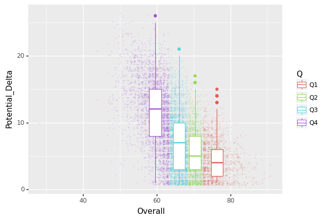

```python
ggplot(data=fifa22.query('Potential_Delta>0.1'))\
+geom_point(aes(x='Overall', y='Potential_Delta',color='Q'),alpha=0.1,size=0.1,position='jitter')\
+geom_boxplot(aes(x='Qx', y='Potential_Delta',color='Q'))
```